# R Notebook

#DGPS Se simularán los 4 procesos generadores de datos y para cada uno se calcularán la media y la varianza. Iniciaremos con el DGP1.

## DGP1

Se crea una función para simular cualquier DGP con la cantidad de simulaciones y observaciones que se desee, también, la deriva, el phi y la desviación estándar del proceso quedarán flexibles. El DGP1, dentro de la función se generará como:
$$x_{t}= \mu + \phi.x_{t-1} + e_{t}$$

**Comparación de la media y varianza con datos simulados y con fórmula** La media y la varianza se estiman desde las fórmulas obtenidas en clase como:
$$E[X_{t}]= \frac{\mu}{1- \phi}\\
VAR(X_{t})= \frac{\sigma_{e}^2}{1- \phi^2}$$
Para el DGP1 se obtienen los siguientes resultados:

|  | Media | Varianza |
| --- | --- | --- |
| Simulado | 4.315532 | 1.764584 |
| Fórmula | 4.333333 | 1.960784 |

Graficamos nuestro DGP1

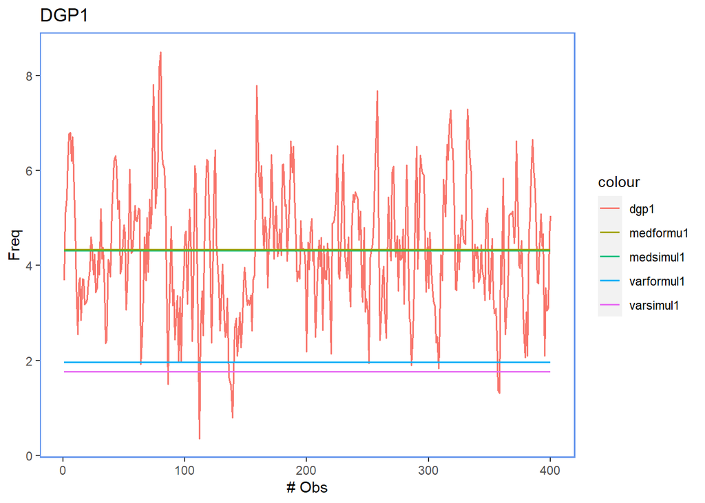

Como se puede ver, para este proceso, al ser un proceso estacionario y autorregresivo, la media y la varianza estimadas por la fórmula y de manera tradicional son bastante parecidas.

# DGP2

El DGP2, dentro de la función se generará como:
$$x_{t}= \mu +\beta.t+ \phi.x_{t-1} + e_{t}$$

Generamos los datos de la simulación con parámetros escogidos e implantamos una semilla
$$N\ obserbaciones=100\\
N \ simulaciones=1\\
\mu=1.3\\
\phi=0.63\\
sd\ proceso=1\\
valor\ inicial=0\\
\beta=0.2$$

**Comparación de la media y varianza con datos simulados y con fórmula** La media y la varianza se estiman desde las fórmulas obtenidas en clase como:
$$E[X_{t}]= \frac{\mu}{1- \phi}-\frac{\phi.\beta}{(1-
\phi)^2}+\frac{\beta.t}{1- \phi}\\
VAR(X_{t})= \frac{\sigma_{e}^2}{1- \phi^2}$$

|  | Media | Varianza |
| --- | --- | --- |
| Simulado | 570.454821252958 | 245.706728938481 |
| Fórmula | depende de t | 1.65809981760902 |

Graficamos nuestro DGP2

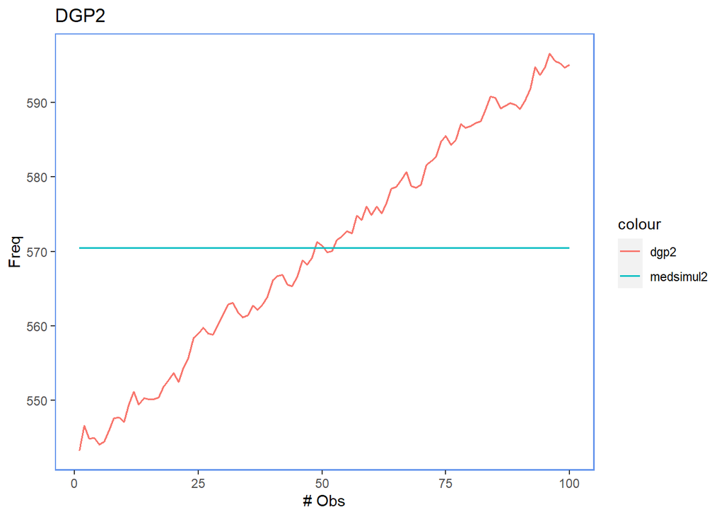

# DGP3

**Comparación de la media y varianza con datos simulados y con fórmula** La media y la varianza se estiman desde las fórmulas obtenidas en clase como:
$$E[X_{t}]= X_{0}\\
VAR(X_{t})= t.\sigma_{e}^2$$

|  | Media | Varianza |
| --- | --- | --- |
| Simulado | 18.9657821574954 | 22.6010730584076 |
| Fórmula | 18.4049360534299 | depende de t |

Graficamos nuestro DGP3

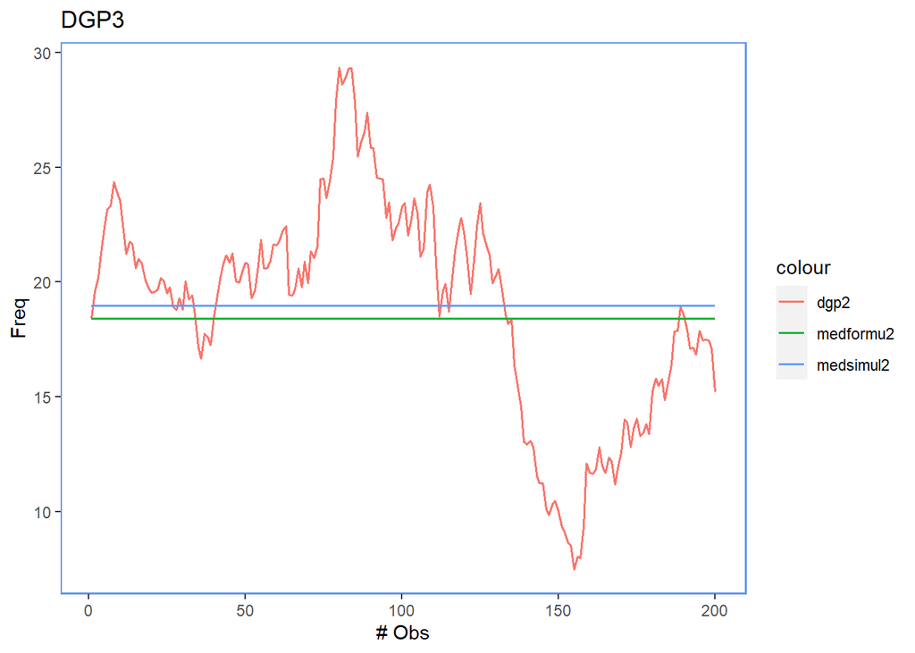

# DGP4

**Comparación de la media y varianza con datos simulados y con fórmula** La media y la varianza se estiman desde las fórmulas obtenidas en clase como:
$$E[X_{t}]= t*\mu+X_{0}\\
VAR(X_{t})= t.\sigma_{e}^2$$

|  | Media | Varianza |
| --- | --- | --- |
| Simulado | 2134.0137723254 | 3266.46437363422 |
| Fórmula | depende del tiempo | depende de t |

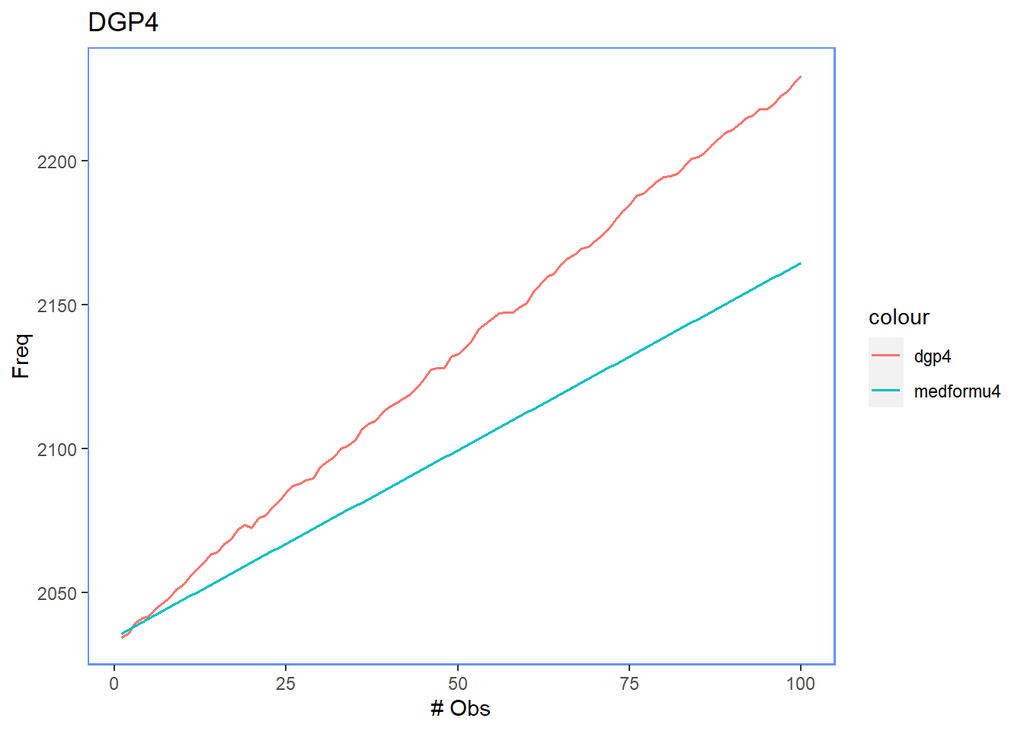